# Estimación

```r
# setwd("~/Dropbox/GitHub/ProbEstad2021")
# To set the working directory realtive to the user's dir
library(rcompanion)
library(tidyverse)
```

# Estimación

El proceso de hacer una estimación, es aquel que nos permite calcular, a partir de una muestra, alguna estadística que es una aproximación al valor real del parámetro de la población de donde la muestra fue tomada.  
**Definición** Inferencia estadística es el procedimiento por el cual podemos alcanzar alguna conclusión acerca de alguna población con base en la información contenida en una muestra extraída de esa población.  
Se encontrará que de cada parámetro que se discuta, se pueden estimar dos tipos de resultados: un **estimado puntual** y un **estimado de intervalo**.  
**Definición** Un estimado puntual es un valor numérico único usado para estimar el parámetro correspondiente de la población.  
**Definición** Un estimado de intervalo consiste en dos valores numéricos que definen el rango de valores entre los que, con algún grado de confianza, muy posiblemente se incluye el parámetro de la población que se está estimando.

## Estimador

Nos hemos referido a un valor único estimado como un estimado único, a esto nos referiremos como un estimador, una fórmula para estimar un valor puntual de una variable aleatoria.  
**Estimador** Un estimador, digamos, T, de un parámetro $\theta$ se dice que no está sesgado cuando $E(T)=\theta$.  
El símbolo $E(T)$ se conoce como el *valor esperado de T*, para una población finita, $E(T)$ se obtiene tomando el valor promedio de $T$ de todas las muestras posibles de un tamaño dado que se puedan extraer de la población de interés. Es decir el valor esperado de $T$, es igual $E(T) = \mu_T$ al promedio de $T$ en la población. Como ya lo comentamos, si el promedio de la distribución muestral de una variable $\bar{x}$ es igual al promedio $\mu$, sabemos que $\bar{x}$ es un estimador no-sesgado de $\mu$ en la población.

## Población muestral y población blanco

**Definición** La población muestral es aquella de donde de extraen las muestras.  
**Definición** La población blanco es aquella de donde se quiere hacer alguna inferencia.  
Estas poblaciones pueden o no, ser la misma población. La estadística nos permite hacer inferencias de las poblaciones muestreadas, suponiendo que el muestreo fue hecho correctamente.

## Intervalo de confianza para el promedio

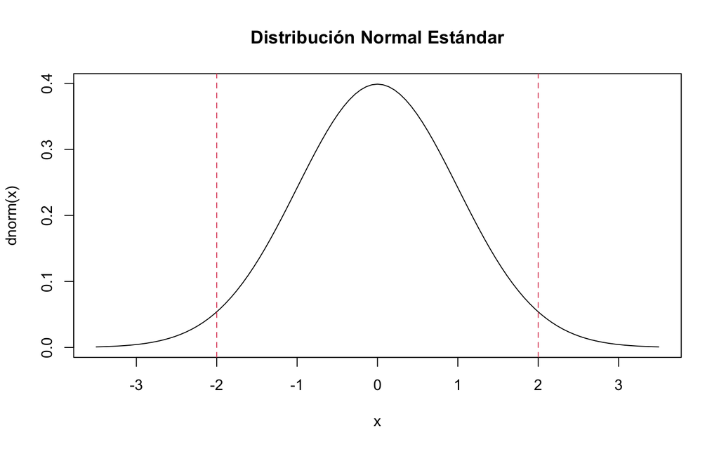

```r
curve(dnorm, from = -3.5, to = 3.5, main = "Distribución Normal Estándar")
abline(v=-2, lty = 2, col = 2)
abline(v= 2, lty = 2, col = 2)
```

## Componentes para estimar el intervalo

Cuando se estima el intervalo de confianza de una estadística que describe a un parámetro de la población se cuenta con el valor central, un valor puntual de $\mu$ estimado, el valor al cual el ancho del intervalo está calculado, por lo general un factor de 2 errores estándar a cada lado del valor central. Estimado con un valor $z$ conocido como el `coeficiente de fiabilidad`

$$\verb+estimador+ \pm (\verb+coeficiente
de fiabilidad+) \times (\verb+error estándar+)$$

En particular cuando el muestreo se hace de una población distribuida normalmente un estimado para el intervalo de $\mu$ es

$$\bar{x} \pm z_{(1 -
\alpha/2)}\sigma_{\bar{x}}$$

en donde $z_{(1 - \alpha/2)}$ es el valor,a la izquierda, de $z$ en donde queda $1-\alpha/2$ y a la derecha $\alpha/2$ del área bajo la curva de la gráfica de probabilidad (escala dada por el corte de probabilidad).

## Interpretación del Intervalo de Confianza

La cantidad $1-\alpha$ en el caso más común $.95$ es llamado el *coeficiente de confianza* (o nivel de fiabilidad), y el intervalo $\bar{x} \pm z_{(1 - \alpha/2)}\sigma_{\bar{x}}$ es llamado el intervalo de confianza para $\mu$. *Interpretación práctica* Cuando un muestreo es tomado de una población distribuida normalmente con desviación estándar conocida, estamos $100(1-\alpha)\%$ confiados de que un único intervalo $\bar{x} \pm z_{(1 - \alpha/2)}\sigma_{\bar{x}}$, contenga el promedio $\mu$ de la población.

**Precisión** La cantidad obtenida al multiplicar el *coeficiente de fiabilidad* por el error estándar, es llamado la precisión de la estimación. Esta cantidad también es llamad **margen de error**.

## Ejemplos

1. Un fisioterapeuta deseaba estimar, con una confianza del 99 por ciento, la fuerza máxima de un músculo en particular, de un grupo de individuos. Está dispuesto a aceptar que los registros de fuerza muscular están aproximadamente distribuidos en forma normal con una varianza de $144 N$. Una muestra de $15$ sujetos que participaron en este experimento resultaron en un promedio de fuerza de $84.3 N$.  
   *Respuesta* Los elementos son: tenemos $\alpha=.01$, $z_{(1-.01/2)} \rightarrow \alpha/2 = .005$ si usamos R para obtener el valor de $z$ para la condición a la derecha de $\alpha/2 = .005$ usamos `qnorm(.005, lower.tail = FALSE)` y el intervalo es

```r
maxi <- 84.3 + qnorm(.005, lower.tail = FALSE)*sqrt(144/15)
mini <- 84.3 + qnorm(.005, lower.tail = TRUE)*sqrt(144/15)

print(c("Intervalo: ", mini, maxi), digits = 4, quote = FALSE)
```

```
[1] Intervalo:       76.3190848037457 92.2809151962543
```

2. En el archivo `EXA_C06_S02_04.csv` se listan los valores de actividad (micromoles por minuto por gramo de tejido) de cierta enzima medida en tejido normal gástrico de 35 pacientes con carcinoma gástrico. Se quiere estimar el intervalo de confianza a 95 por ciento del promedio de la población. Suponga que conocemos que la varianza de la población es 0.36. No es necesario suponer que los valores de muestreo siguen una distribución normal, ya que el número de muestras es suficientemente grande

```r
ensyme <- read_csv("~/Dropbox/GitHub/ProbEstad/DataSets/ch06_all/EXA_C06_S02_04.csv", col_names = TRUE, show_col_types = FALSE)
#
CI(ensyme$ACTIVITY, ci=0.95)
```

```
    upper      mean     lower
0.8924181 0.7166857 0.5409533
```

```r
# Estimado con función de rcompanion
groupwiseMean(ACTIVITY ~ 1,
              data   = ensyme,
              conf   = 0.95,
              digits = 3)
```

```
   .id  n  Mean Conf.level Trad.lower Trad.upper
1 <NA> 35 0.717       0.95      0.541      0.892
```

```r
# estimado con una prueba t
t.test(ensyme$ACTIVITY, alternative = c("two.sided"), var.equal = .36, conf.level = 0.95)
```

```
    One Sample t-test

data:  ensyme$ACTIVITY
t = 8.2881, df = 34, p-value = 1.131e-09
alternative hypothesis: true mean is not equal to 0
95 percent confidence interval:
 0.5409533 0.8924181
sample estimates:
mean of x
0.7166857
```

## t de Student

A principio del siglo veinte se publicaron varios trabajos de suma importancia por un estadístico de nombre “Student”. En realidad Student era en nombre de autor de William Gosset.  
William Sealy Gosset (1876-1937), el estadístico inglés que desarrolló la distribución t y la prueba t mientras trabajaba como cervecero en la cervecería Guinness en Dublín, se vio obligado a publicar bajo el seudónimo “Student” debido a las estrictas políticas de confidencialidad de su empleador. Esta política de secreto, desencadenada por un incidente anterior en el que un investigador de Guinness reveló secretos comerciales en una publicación, dio forma a la recepción del trabajo de Gosset. El seudónimo ocultó su identidad durante décadas, retrasó el reconocimiento de sus contribuciones y creó una curiosa dinámica entre Gosset, Karl Pearson y Ronald Fisher que influyó en el desarrollo de la estadística moderna.  
William Gosset fue contratado por Guinness como químico y cervecero y rápidamente se convirtió en jefe cervecero experimental; más tarde fue ascendido a jefe cervecero de la cervecería Guinness Park Royal y, en última instancia, a jefe cervecero para todo Guinness.  
La tarea de Gosset como aprendiz de cervecero era evaluar la calidad de las materias primas (cebada malteada, lúpulo y levadura) de una manera rentable. Esto requirió sacar conclusiones de un pequeño número de observaciones experimentales, ya que las pruebas a gran escala eran poco prácticas y costosas. Fue precisamente esta restricción práctica la que lo llevó a desarrollar lo que se convirtió en la distribución t de Student.

## La distribución t

Hasta ahora hemos establecido los procedimientos para estimar el intervalo de confianza de un proceso de muestreo, y en dicho proceso se ha dado por conocida la varianza de la población de donde se extrajeron las muestras. Por lo general si no se tiene el promedio de la población es muy posible que tampoco se conozca a varianza, y por lo tanto se tendrá que estimar de la muestra. lo que genera un problema. Entre las herramientas con las que contamos para resolver este problema se sabe que la estadística

$$z=\frac{\bar{x}-\mu}{\sigma/\sqrt{n}}$$
está distribuida normalmente cuando la población está distribuida normalmente o por lo menos está distribuida de forma parcialmente normal para valores grandes de $n$, independientemente de la distribución de la población. Se puede usar la desviación estándar de la muestra

$$s = \sqrt{\sum_i^n{(x_i -
\bar{x})^2}/(n-1)}$$
para reemplazar $\sigma$. Cuando la muestra es grande, mayor a **30**, el parámetro muestral $s$ se considera bueno. Se sabe que para muestras de buen tamaño se tiene la *Distribución $t$ de Student* o distribución $t$

$$t= \frac{\bar{x}-\mu}{s/\sqrt{n}}$$

## Propiedades de la distribución t.

1. Tiene promedio $0$.
2. Es simétrica al promedio.
3. Por lo general tiene una varianza mayor que $1$, pero la varianza se aproxima a $1$ cuando el tamaño de la muestra se hace grande. Y por lo general para $df (degrees of fredom)$ grados de libertad, para $df >2$ la varianza de *t* es $df/(df -2)$. Como $df = n-1$ para $n>3$ la varianza de la $t$ se puede escribir como $(n-1)/(n-3)$ para $n>3$.
4. El rango de la variable $t$ va de $-\infty$ a $\infty$.
5. La distribución $t$ en realidad es una familia de distribuciones que tienen diferentes distribuciones para diferentes drados de libertad ($df$).
6. Comparado con la distribución normal la $t$ tiene un máximo central más bajo y cuerpo central más angosto y las colas más anchas.
7. La distribución $t$ tiende a la distribución normal para $(n-1) \rightarrow \infty$.

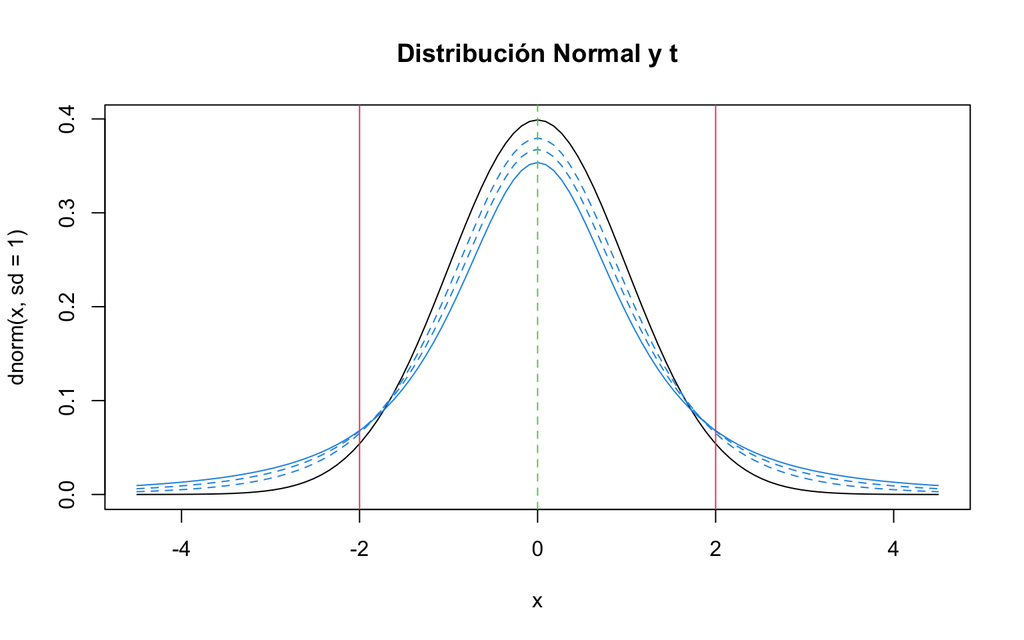

```r
curve(dnorm(x, sd = 1), from = -4.5, to = 4.5, main = "Distribución Normal y t")
curve(dt(x, df = 2), col = 4, from = -4.5, to = 4.5, add = TRUE)
curve(dt(x, df = 3), col = 4, lty = 2, from = -4.5, to = 4.5, add = TRUE)
curve(dt(x, df = 5), col = 4, lty = 2, from = -4.5, to = 4.5, add = TRUE)
abline(v=0, lty = 2, col = 3)
abline(v=-2, col = 2)
abline(v=2, col = 2)
```

## Intervalo de confianza usando $t$

El procedimiento general para estimar los intervalos de confianza no cambia al usar la distribución $t$ en lugar de la normal. Se usa el mismo algoritmo

$$\verb+estimador+ \pm (\verb+coeficiente
de fiabilidad+) \times (\verb+error estándar+)$$
La diferencia es el origen para el coeficiente de fiabilidad, que en este caso se obtiene de una función $t$. Para una muestra de una distribución normal, con varianza desconocida el intervalo de confianza del $100(1-\alpha)$ por ciento para el promedio de la población, está dado por

$$\bar{x} \pm
t_{(1-\alpha/2)}\frac{s}{\sqrt{n}}$$

## Ejemplos

1. Maffulli et al. estudiaron la efectividad de terapias que limitan carga y movilidad del tobillo, como seguimiento al tratamiento a ruptura del tendón de Aquiles, midieron la fuerza en un músculo del tobillo. En 19 sujetos, la fuerza promedio isométrica medida en el tobillo intervenido (en Newtons) fue de 250.8 con una desviación estándar de 130.9. Si suponemos que la muestra aleatoria fue tomada de una población de sujetos control. Queremos usar estas medidas de la muestra para estimar la fuerza isométrica de la población después de una cirugía.  
   *Respuesta* Vamos a estimar un intervalo de confianza a 95 por ciento de confianza. Tenemos $\bar{x} = 250.8$, y $s=130.9$, primero estimamos el error estándar $se = s/\sqrt{n}$

```r
# Intervalo conf. con t
muestra.n <- 19
muestra.sd <- 130.9
muestra.se <- muestra.sd/sqrt(muestra.n)
# coef. conf.
alpha <- 0.05
grados.lib <- muestra.n - 1
(t.score <- qt(p=alpha/2, df = grados.lib, lower.tail=FALSE))
```

```
[1] 2.100922
```

```r
# Intervalo
marg.error <- t.score * muestra.se
#
lim.bajo <- 250.8 - marg.error
lim.alto <- 250.8 + marg.error
#
print(c(lim.bajo, lim.alto))
```

```
[1] 187.7082 313.8918
```

2. (Daniel6.3.1) Use la distribución t para estimar el factor de fiabilidad para el intervalo de confianza usando los siguientes niveles de confianza y tamaños de muestra

$$\begin{array}{lcccc}
& a & b & c & d \\
\hline
{\verb+Nivel de confianza+} & .95 & .99 & .90 & .95 \\
{\verb+Tamaño de muestra+} & 15 & 24 & 8 & 30 \\
\hline
\end{array}$$

```r
# a
muestra.n <- 15
alpha <- 0.05
grados.lib <- muestra.n - 1
(t.score <- qt(p = alpha/2, df = grados.lib, lower.tail=FALSE))
```

```
[1] 2.144787
```

```r
#b
muestra.n <- 24
alpha <- 0.01
grados.lib <- muestra.n - 1
(t.score <- qt(p = alpha/2, df = grados.lib, lower.tail=FALSE))
```

```
[1] 2.807336
```

```r
#c
muestra.n <- 8
alpha <- 0.1
grados.lib <- muestra.n - 1
(t.score <- qt(p = alpha/2, df = grados.lib, lower.tail=FALSE))
```

```
[1] 1.894579
```

```r
#d
muestra.n <- 30
alpha <- 0.05
grados.lib <- muestra.n - 1
(t.score <- qt(p = alpha/2, df = grados.lib, lower.tail=FALSE))
```

```
[1] 2.04523
```

## Intervalo de confianza para la diferencia entre el promedio de dos poblaciones

Frecuentemente es necesario estimar el intervalo de confianza de la diferencia del promedio de dos poblaciones. De cada una de las poblaciones se extrae una muestra aleatoria, y de estas muestras se estima la media $\bar{x}_1$ y $\bar{x}_2$, en donde la diferencia $\bar{x}_1-\bar{x}_2$ es el estimador para $\mu_1 - \mu_2$. La varianza del estimador es estimada por $(\sigma_1^2/n_1)+(\sigma_2^2/n_2)$. Cuando las varianzas de las poblaciones se conocen el intervalo de confianza al $100(1-\alpha)$ por ciento de la diferencia $\mu_1-\mu_2$ es

$$(\bar{x}_1 - \bar{x}_2) \pm
z_{1-\alpha/2} \sqrt{ \frac{\sigma_1^2}{n_1} + \frac{\sigma_2^2}{n_2} }$$

**La distribución t y la diferencia entre promedios** Cuando se quiere estimar la diferencia entre los promedios de dos poblaciones y no se conoce la varianza de las poblaciones, es necesario estimar la varianza de las poblaciones a partir de las **varianzas de las muestras** y se puede usar la distribución t para estimar el valor de confiabilidad. En lo general se tendrán dos posibilidades, que las varianzas de las poblaciones que se estudian tengan igual o diferentes varianzas.

*Para varianzas iguales* Si se puede suponer que la varianza de las poblaciones es igual y se quiere estimar la diferencia del promedio de las poblaciones se puede usar lo que se conoce como un *valor combinado* de las varinazas muestrales (pooled estimate).

El valor combinado se estima por la siguiente ecuación

$$s_p^2 = \frac{(n_1 - 1)s_1^2 + (n_2 -
1)s_2^2}{n_1 + n_2 -2}$$

El error estándar del valor combinado es

$$s_{\bar{x}_1 - \bar{x}_2} = \sqrt{
\frac{s_p^2}{n_1} + \frac{s_p^2}{n_2} }$$

y el intervalo de confianza al $100(1-\alpha)$ por ciento para $\mu_1 - \mu_2$ está dado por
$$(\bar{x}_1 - \bar{x}_2) \pm
t_{(1-\alpha/2)} \sqrt{ \frac{s_p^2}{n_1} + \frac{s_p^2}{n_2}
}$$

El número de grados de libertad para estimar el valor de *t* para usar en la estimación del intervalo esta dado por $df = n_1 + n_2 -2$.

*ejemplo* El propósito del estudio de Granholm et al. fue determinar la efectividad del tratamiento integrado por el programa ambulatorio integrado de doble diagnóstico para pacientes de salud mental. Los investigadores estaban evaluando problemas de abuso de sustancias entre pacientes con desorden mental severo. Una tabla retrospectiva de revisión se llevó a cabo en 50 pacientes consecutivos referidos a un programa. Una de las variables usadas en dicho programa fue el número de días de internamiento por el desorden psiquiátrico durante el año que siguió al programa. Entre 18 pacientes con esquizofrenia, el promedio el numero promedio de días de tratamiento fue de 4.7 con una desviación estándar de 9.3. Para 10 pacientes con desorden bipolar el promedio de días de tratamiento psiquiátrico fue de 8.8 con desviación estándar de 11.5. Queremos construir un intervalo de confianza del 95 por ciento de la diferencia entre los promedios de estas poblaciones.

```r
# Intervalo conf. con t
# población 1
muestra.n1 <- 18
muestra.sd1 <- 9.3
# población 2
muestra.n2 <- 10
muestra.sd2 <- 11.5
# desviación combinada
sd_p <- ( (muestra.n1 - 1)*muestra.sd1^2 + (muestra.n2 - 1)*muestra.sd2^2 )/(muestra.n1 + muestra.n2 - 2)
# error estándar
serr_p <- sqrt( sd_p/muestra.n1 + sd_p/muestra.n2)
# coef. conf.
alpha <- 0.05
grados.lib <- muestra.n1 + muestra.n2 - 2
(t.score <- qt(p=alpha/2, df = grados.lib, lower.tail=FALSE))
```

```
[1] 2.055529
```

```r
# Intervalo
marg.error <- t.score * serr_p
#
lim.bajo <- (4.7 - 8.8) - marg.error
lim.alto <- (4.7 - 8.8) + marg.error
#
print(c(lim.bajo, lim.alto))
```

```
[1] -12.301022   4.101022
```

## Estimación del tamaño de muestra para el cálculo de la media

La estimación del tamaño de la muestra a obtener para resolver una medida, es desde el inicio del proyecto un tema fundamental de suma importancia. Una muestra muy grande resulta en un uso excesivo de recursos y una muestra muy pequeña puede no tener el poder estadístico necesario para determinar un resultado fiable.

El objetivo de la estimación en estadística es obtener intervalos estrechos que resulten en estimaciones más precisas. Una forma de darnos cuenta lo los elementos necesarios es analizar los componentes usados para estimar el intervalo de confianza.
$$(\verb+coeficiente de fiabilidad+) \times
(\verb+error estándar+)$$

la extensión total del intervalo de confianza es dos veces este factor, y este parámetro se puede entender como el estimador del margen de error. Para un error estándar, incrementar la fiabilidad, implica un coeficiente de fiabilidad mayor, pero esto resulta en un intervalo más ancho. Cómo el margen de error está dado por $\sigma/\sqrt{n}$ y $\sigma$ es constante para una población, esto implica que la única forma de reducir el error estándar es adquiriendo una muestra mayor con $n$ más grande.

Supongamos que queremos un intervalo que se extienda $d$ unidades a cada lado del estimador
$$d = (\verb+coeficiente de fiabilidad+)
\times (\verb+error estándar+)$$
Si el muestreo se toma con sustitución de una población infinita, o de una población suficientemente grande, que permita ignorar la corrección de población finita, la ecuación para $d$ es

$$d = z\frac{\sigma}{\sqrt{n}}$$

Que si la resolvemos para la variable $n$ resulta en

$$n = \frac{z^2\sigma^2}{d^2}$$
Si el muestreo se toma sin sustitución de una población infinita, o de una población suficientemente grande, la ecuación que incluye la corrección de población finita es

$$d =
z\frac{\sigma}{\sqrt{n}}\sqrt{\frac{N-n}{N-1}}$$
que al resolver para $n$ es igual a
$$n = \frac{Nz^2\sigma^2}{d^2(N-1) +
z^2\sigma^2}$$
Cuando la corrección para población finita puede ser ignorada está última ecuación se reduce a al anterior para $n$.

**Estimación de** $\sigma^2$ estas fórmulas para la estimación de el tamaño de la muestra, requieren del valor de $\sigma$ que como ya se dijo antes es una variable que por los general es desconocida. Por lo tanto la varianza poblacional $\sigma^2$ se tiene que estimar de alguna forma.  
1. Por medio de alguna estudio *piloto*  
2. Estimados de $\sigma^2$ se pueden tener de otros estudios similares.  
3. Si la población de donde se esta tomando la muestra es normal o aproximadamente normal y se conoce el rango de la población la desviación estándar se puede estimar a partir del rango $R$ que es aproximadamente 6 veces la desviación estándar $\sigma \approx R/6$.

## Estimación del tamaño de muestra para estimaciones de proporciones

Cuando se está trabajando con estimación de proporciones de una población y el muestreo se toma sin sustitución de una población infinita, o de una población suficientemente grande, y no es necesario incluir la corrección de población finita el tamaño de muestra para un intervalo de una proporción es

$$n = \frac{z^2pq}{d^2}$$

con $q = (1-p)$, Y si la corrección de población finita no se puede ignorar

$$n = \frac{Nz^2pq}{d^2(N-1) + z^2pq}$$
Ambas fórmulas hacen uso de $p$ que representa la proporción de la población, y es una variable que es desconocida. Como en el caso de $\sigma$ Se puede hacer un estudio piloto para hacer una estimación de este parámetro. Y en ocasiones se tiene una idea de la proporción máxima de la población, y en eses caso se puede usar como el valor de $p$. O en un caso dado se puede tener un valor de $p$ blanco que se quiere estudiar.

## El intervalo de confianza para la varianza de una distribución distribuida normalmente

**Estimación puntual de la varianza** Como ya hemos comentado, para tener un bune estimador del valor central de un parámetro poblacional, este debe estar estimado libre de tendencias. Proponemos que un buen estimador de la varianza es el valor esperado para la varianza de la muestra $E(s^2) = \sigma^2$. Los dos valores de dispersión que conocemos son

$$\sigma^2 = \frac{\sum(x_i - \mu)^2}{N}
\; y \; S^2 = \frac{\sum(x_i - \mu)^2}{N-1}$$

Si se estima el promedio de las varianzas de todas las posibles muestras de tamaño $n$ tomadas de una población se llega a la estimación de $s^2 = \sum(x_i - \bar{x})^2/(n-1)$.

## La distribución Chi-cuadrada

Se tiene que para una distribución normal para una serie de muestras la cantidad $(n-1)s^2/\sigma^2$ sigue una distribución llamada *chi-cuadrada* $\chi^2$, con $n-1$ grados de libertad.  
Para estimar un intervalo de confianza de la varianza poblacional, se puede usar esta distribución, y un intervalo $100(1-\alpha)$ por ciento de la varianza se puede estimar a partir de

$$\chi_{\alpha/2}^2 <
\frac{(n-1)s^2}{\sigma^2} <\chi_{1-(\alpha/2)}^2$$

que resulta en

$$\frac{(n-1)s^2}{\chi_{1- (\alpha/2)}^2}
< \sigma^2 < \frac{(n-1)s^2}{\chi_{\alpha/12}^2}$$

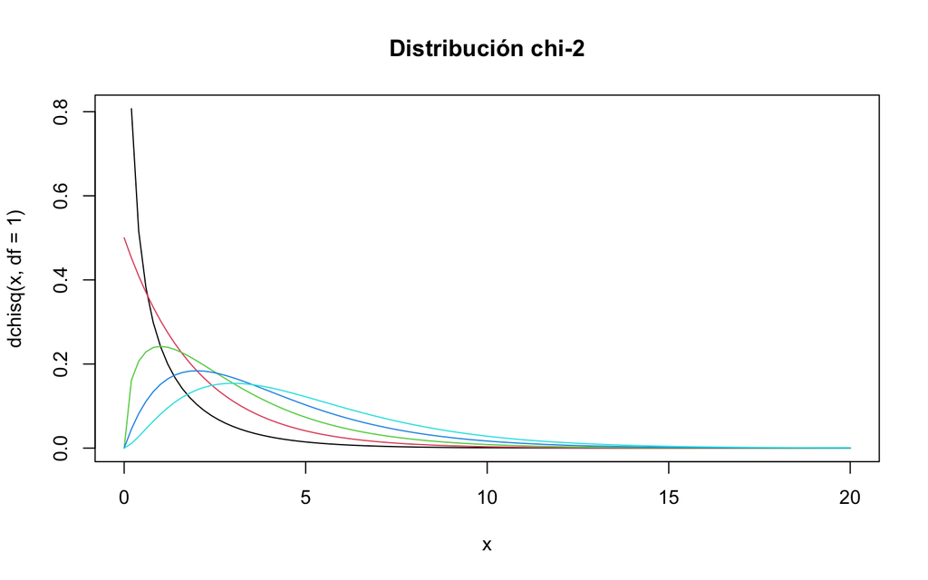

```r
curve(dchisq(x, df = 1), from = 0, to = 20, main = "Distribución chi-2")
curve(dchisq(x, df = 2), from = 0, to = 20, col = 2, add = TRUE)
curve(dchisq(x, df = 3), from = 0, to = 20, col = 3, add = TRUE)
curve(dchisq(x, df = 4), from = 0, to = 20, col = 4, add = TRUE)
curve(dchisq(x, df = 5), from = 0, to = 20, col = 5, add = TRUE)
```

**Ejemplo** En un ejemplo de la efectividad de la dieta libre de gluten en parientes directos de pacientes con diabetes tipo-I, Hummel et al. pusieron a 7 sujetos a una dieta libre de gluten por 12 meses. Antes de la dieta, tomaron medidas de base de varios anticuerpos y autoanticuerpos, uno de ellos relacionado con diabetes el autoanticuerpo relacionado a insulina (IAA). Los niveles de IAA se midieron por medio de ensayos de radiobinding. Los niveles base de IAA de los siete sujetos en unidades base de IAA son:

$$9.7, 12.3, 11.2, 5.1, 24.8, 14.8, 17.7$$
Con estos datos queremos estimar la varianza de IAA en unidades de IAA de la población de donde se tomó esta muestra y construir el intervalo de confianza al $95$ por ciento $(\alpha = .05)$ de dicha estimación.
Vamos a escribir una función para estimar intervalos de confianza usando la función `qchisq(z, df)` de R, que estima la distribución $\chi^2$, y la expresión para el intervalo:

$$\frac{(n-1)s^2}{\chi_{1- (\alpha/2)}^2}
< \sigma^2 < \frac{(n-1)s^2}{\chi_{\alpha/12}^2}$$

*Respuesta*

```r
# Función 'CI_sig' para estimar el intervalo de conviaza para la Varianza, a
# partir de una muestra tomada de una población que se asume está distribuída
# normalmente.
CI_sig <- function(x, alpha) {
    sd_x <- sd(x)
    n_x <- length(x)
    lbs <- sqrt((n_x - 1) * sd_x^2/qchisq((1 - alpha/2), (n_x - 1)))
    las <- sqrt((n_x - 1) * sd_x^2/qchisq(alpha/2, (n_x - 1)))
    print(c("Desviación estandar estimada", sd_x), quote = FALSE)
    print(c("Intervalo de confianza de la desviación estándar"), quote = FALSE)
    print(c(lbs, las))
}

# Ejemplo de Hummel
IAA <- c(9.7, 12.3, 11.2, 5.1, 24.8, 14.8, 17.7)
CI_sig(IAA, 0.05)
```

```
[1] Desviación estandar estimada 6.30577966177515
[1] Intervalo de confianza de la desviación estándar
[1]  4.063403 13.885744
```

**Ejemplo** Veinte muestras de aire tomadas en el mismo lugar a lo largo de 6 meses mostraron las siguientes cantidades de partículas materiales suspendidas (microgramos por metro cubico de aire): 68 22 36 32 42 24 28 38 30 44 28 27 28 43 45 50 79 74 57 21  
Considere estas medidas como una muestra aleatoria normalmente distribuida, y construya un intervalo de confianza al 95 por ciento de la varianza de esta población de partículas suspendidas.

*Respuesta* Vamos a usar la función `CI_sig(x, alpha = 0.05)` para estimar el intervalo de confianza.

```r
ParSus <- c(68, 22, 36, 32, 42, 24, 28, 38, 30, 44, 28, 27, 28, 43, 45, 50, 79, 74, 57, 21)
CI_sig(ParSus, .05)
```

[output not shown]

## Intervalo de confinaza para la proporción de las varianzas de dos poblaciones

Es muy común que se quieran comparara las varinazas de dos poblaciones, esto es posible usando la expresión para la proporción $\sigma_1 / \sigma_2$, es claro que si las varianzas de las dos poblaciones son iguales esta proporción será igual a 1.

**La distribución F.** Bajo propiedades específicas la relación matemática $(s_1^2/\sigma_1^2)/(s_2^2/\sigma_2^2)$ sigue una distribución $F$, que depende de dos grados de libertad, uno correspondiente a $(n_1 -1)$ y el otro $(n_2 - 1)$. Hay que mencionar que al igual que la distribución $\chi^2$, la distribución $F_{\alpha, df_1, df_2}$ no es una distribución simétrica.

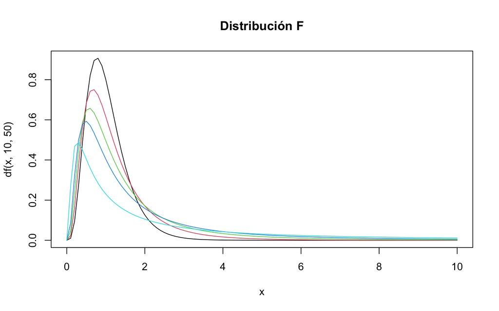

```r
curve(df(x, 10, 50), from = 0, to = 10, main = "Distribución F")
curve(df(x, 10, 10), from = 0, to = 10, col = 2, add = TRUE)
curve(df(x, 10, 5), from = 0, to = 10, col = 3, add = TRUE)
curve(df(x, 10, 3), from = 0, to = 10, col = 4, add = TRUE)
curve(df(x, 10, 1), from = 0, to = 10, col = 5, add = TRUE)
```

El tema de la varianza es un tema muy importante cuando se quieren sacar conclusiones de medidas de valor central por medio de muestreo. Una conclusión muy importante es que **cuando las varinazas de dos poblaciones son distintas no se deben comparar los promedios de las poblaciones**, ya que se puede llegar a conclusiones erróneas.

Para estimar el intervalo de confianza de la proporción de las varianzas de dos poblaciones $\sigma_1^2/\sigma_2^2$ se usa la relación

$$F_{\alpha/2} <
\frac{s_1^2/\sigma_1^2}{s_2^2/\sigma_2^2} < F_{1-(\alpha/2)}$$

que después de despejar la relación para la proporcion de las varinzas de las poblaciones resulta en

$$\frac{s_1^2/s_2^2}{F_{1-(\alpha/2)}}
< \frac{\sigma_1^2}{\sigma_2^2} < \frac{s_1^2/s_2^2}{F_{\alpha/2}}$$

Para el caso de la estimación de la proporción de la desviación estándar de muestras de dos poblaciones se puede usar la función en R `var.test()` que además de hacer una estimación del intervalo de confianza hace una medida de la probabilidad por $F$.

**Ejemplo** Allen y Gross examinaron la fuerza del flexor del dedo gordo del pie de pacientes con fascitis plantar, una condición común en pacientes con problemas musculoesqueléticos. El tratamiento de la facitis plantar es un tratamiento costoso y muchas veces poco efectivo. Una de las medidas de base de los paciente fue su índice de masa corporal (BMI, por sus siglas en inglés). Para 16 de las mujeres de este estudio, la desviación estándar para BMI fue de $s_1 = 8.1$ y para los cuatro hombres en el estudio, la desviación estándar fue de $s_2 = 5.9$. Queremos considerar un intervalo de confianza al 95% para la proporción de las desviaciones estándar de las poblaciones en el estudio.

*Respuesta* Los datos que tenemos son, $n_1 = 16$, y $n_2 =4$ con $s_1 = 8.1$ y $s_2 = 5.9$, para los grados de libertad de la función $\chi^2$ tenemos $df_1 = n_1 - 1 = 15$ y $df_2 = n_2 - 1 = 3$ y usando la ecuación para la proporción de las vatianzas $\sigma_1^2/\sigma_2^2$

```r
# Para s_1/s_2, df2 = 15, df1 = 3
s_prop <- (8.1)^2/(5.9)^2
# s_prop/F(.975) < sigmas < s_prop/F(.025)
LBI <- s_prop/qf(.975, 15, 3)
LAI <- s_prop/qf(.025, 15, 3)

print(c(LBI, LAI))
```

```
[1] 0.1322417 7.8272184
```

Para obtener los valores críticos de $F_{(1-\alpha/2), df_1, df_2}$ o $F_{\alpha/2, df_1, df_2}$ se usó la funcion base de R que estima el área bajo la curva de la distribución *F*: `qf(.975, df1, df2)` o `qf(.025, df1, df2)`.

**Ejemplo** El propósito del estudio de Moneim et al. fue examinar amputaciones del dedo índice por accidentes durante competencias de laso en rodeos. Los investigadores revisaron 16 casos de amputaciones de índice. De estás, 11 fueron amputaciones totales mientras 5 fueron parciales. El tiempo de isquemia es la longitud de tiempo de suministro de oxígeno insuficiente al índice amputado.

Los tiempos de isquemia (en horas) para los sujetos que experimentaron amputación completa fueron:

`4.67, 10.5, 2.0, 3.18, 4.00, 3.5, 3.33, 5.32, 2.0, 4.25, 6.0`

Para las víctimas de amputación parcial, los tiempos de isquemia fueron:

`3.0, 10.25, 1.5, 5.22, 5.0`

Considere los dos grupos de datos como normalmente distribuidos y que representan a dos poblaciones independientes y construya el intervalo de confianza al 95% de la proporcion de las varianzas de las dos poblaciones.

*Respuesta* Usando la teoría presentada anteriormente puedo desarrollar la función `PropVar_CI` para calcular el intervalo de confianza para la proporción de las varianzas de los dos grupos de datos, descrita a continuación:

```r
# Proportion of Variance for two populations confidence interval This small
# function estimates the confidence interval for the proportion of the
# variances estimated form two samples

PropVar_CI <- function(x, y, alpha = 0.05) {
    v_x <- var(x)
    n_x <- length(x)
    v_y <- var(y)
    n_y <- length(y)
    if (v_x > v_y) {
        pro_v <- v_x/v_y
        in_lim <- pro_v/qf((1 - alpha/2), (n_x - 1), (n_y - 1))
        su_lim <- pro_v/qf((alpha/2), (n_x - 1), (n_y - 1))
    } else {
        pro_v <- v_y/v_x
        in_lim <- pro_v/qf((1 - alpha/2), (n_y - 1), (n_x - 1))
        su_lim <- pro_v/qf((alpha/2), (n_y - 1), (n_x - 1))
    }
    result <- c(in_lim, su_lim)
    return(result)
}

com_am <- c(4.67, 10.5, 2, 3.18, 4, 3.5, 3.33, 5.32, 2, 4.25, 6)
inc_am <- c(3, 10.25, 1.5, 5.22, 5)
res <- PropVar_CI(com_am, inc_am, alpha = 0.05)
print(res)
```

```
[1]  0.4395909 17.3715266
```

Y de forma mucho más directa se puede usar la función `var.test`, incluida en la librería base de R, que nos da la misma repuesta de forma directa, la cual además de estimar el intervalo de confianza nos da una prueba completa con pobabilidad de la poporción de las varianzas:

```r
var.test(inc_am, com_am, conf.level = 0.95)
```

```
    F test to compare two variances

data:  inc_am and com_am
F = 1.9642, num df = 4, denom df = 10, p-value = 0.3525
alternative hypothesis: true ratio of variances is not equal to 1
95 percent confidence interval:
  0.4395909 17.3715266
sample estimates:
ratio of variances
          1.964242
```